# Les 200 principales revues de Marketing

cb

2022-08-28

## Les outils

[Source scimago Institution Ranking](https://www.scimagojr.com/journalrank.php?category=1406)

```r
library(tidyverse)
library(readr)
library(ggcorrplot)
library(FactoMineR)
library(factoextra)
library(ggrepel)
library(viridis)
theme_set(theme_minimal())

df <- read_delim("scimagojr 2021  Subject Category - Marketing 2.csv",
    delim = ";", escape_double = FALSE, trim_ws = TRUE)
```

## Corrélations

Manifestement deux éléments : la production et les citations de ces productions.

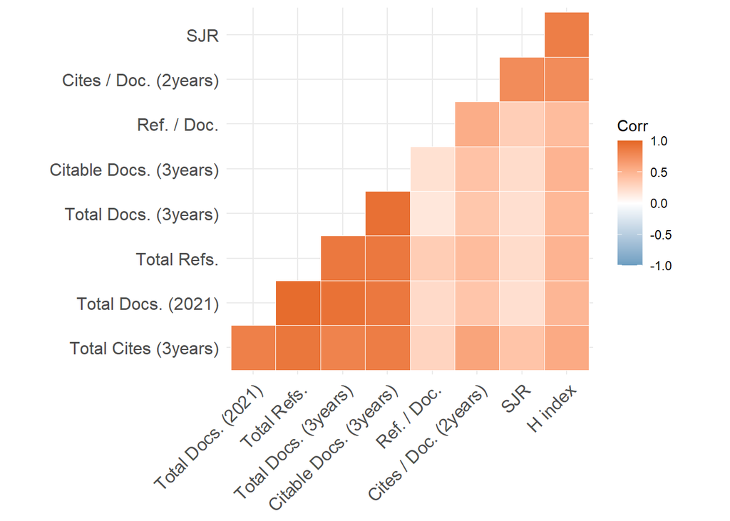

```r
cor<-df %>% column_to_rownames("Title") %>% select(5,7:14)%>%
   drop_na()
r<-cor(cor)

ggcorrplot(r, hc.order = TRUE, type = "lower",
   outline.col = "white",
   colors = c("#6D9EC1", "white", "#E46726"))
```

```r
ggsave("journal00.jpg", plot=last_plot(),width = 28, height = 19, units = "cm")
```

## Une petite ACP

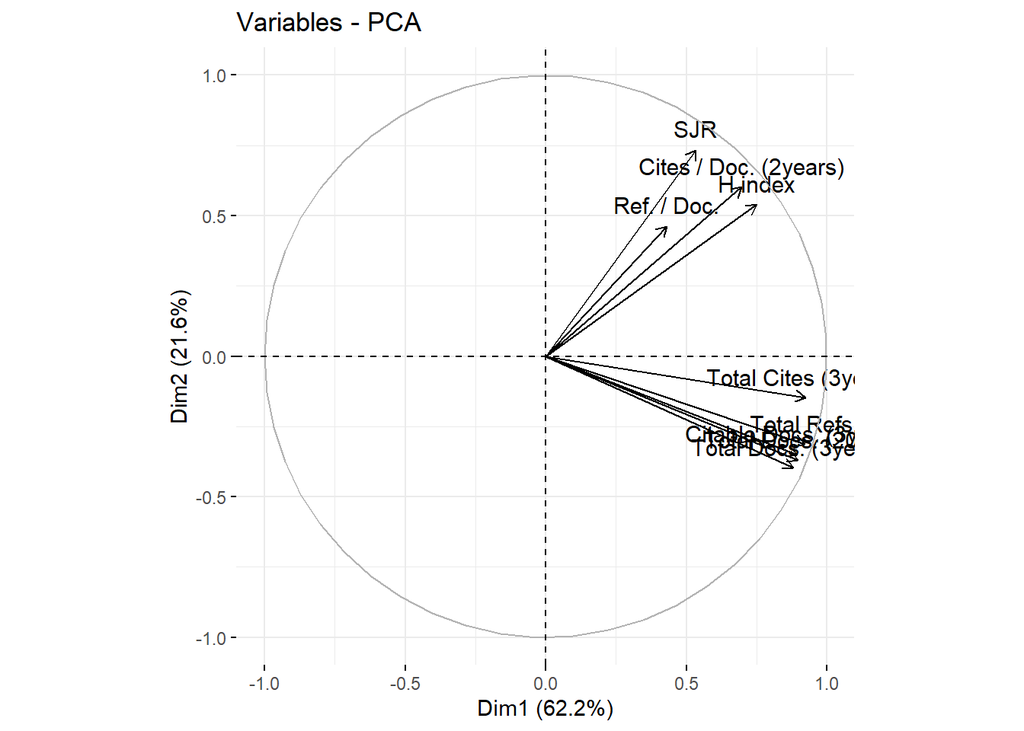

```r
res.pca <- PCA(cor, graph = FALSE)

fviz_pca_var(res.pca)
```

```r
ggsave("journal01.jpg", plot=last_plot(),width = 28, height = 19, units = "cm")
```

## Le tableau final

remarques :

- Deux anomalies, une revue plutôt IS mais qui publient certainement des papiers à applications marketing, et Journal of Business Research, dont la production annuelles écrasent ses concurrents, son score de citation est certainement lié à cette stratégie d’acceptation élargie. (Il manque d’ailleurs à ces indicateurs, un indicateur de taux d’acceptation…)
- Une corrélation générale plutôt positive entre production et citations, plus on produit et mieux on est cité , du point de vue des revues.
- L’hégémonie UK-USA, mais les pays bas qui tirent leur épingle du jeu.

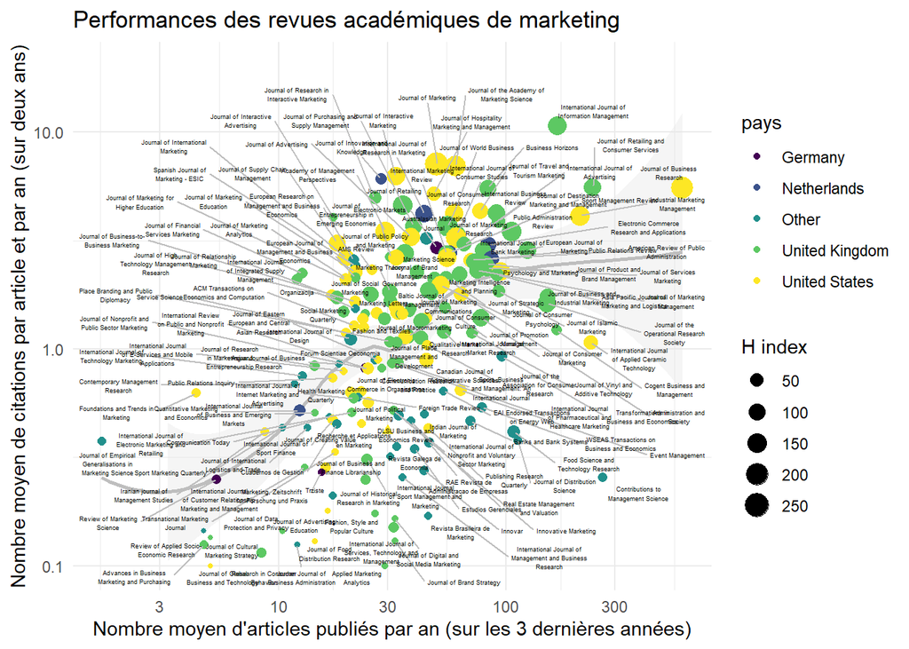

```r
df$pays<-fct_lump_min(df$Country, min =5) %>% as.character()
df$ram[df$Issn=="20515707"]<-"Rech. et Appl. en Mark."
df$ram[df$Issn!="20515707"]<-"Autres"


df<-df %>%filter(`Cites / Doc. (2years)`>0.1)


ggplot(df, aes(x=`Total Docs. (3years)`/3, y=`Cites / Doc. (2years)`/2))+
   geom_smooth(color="grey", fill="Grey90")+
   geom_point(aes(color= pays, size=`H index`,shape=ram))+
   geom_text_repel(size=1.2, max.overlaps=40,segment.color="grey",
                   segment.shape    =0.1,aes(label=str_wrap(Title, 25)))+
   scale_x_continuous(trans="log10")+
   scale_y_continuous(limits=c(0.1,20),trans="log10")+
   labs(title="Performances des revues académiques de marketing",
        x= "Nombre moyen d'articles publiés par an (sur les 3 dernières années)",
        y= "Nombre moyen de citations par article et par an (sur deux ans)")+
   guides(shape="none")+scale_colour_viridis_d()
```

```r
ggsave("journal02.jpg", plot=last_plot(),width = 28, height = 19, units = "cm")
```

## Des suppléments

Les pays et leur performances, on s’interrogera sur le cas français en le comparant au cas allemand.

Et finalement, le nombre de citations dans un article qui semble plutôt homogène.(de l’ordre de 70)

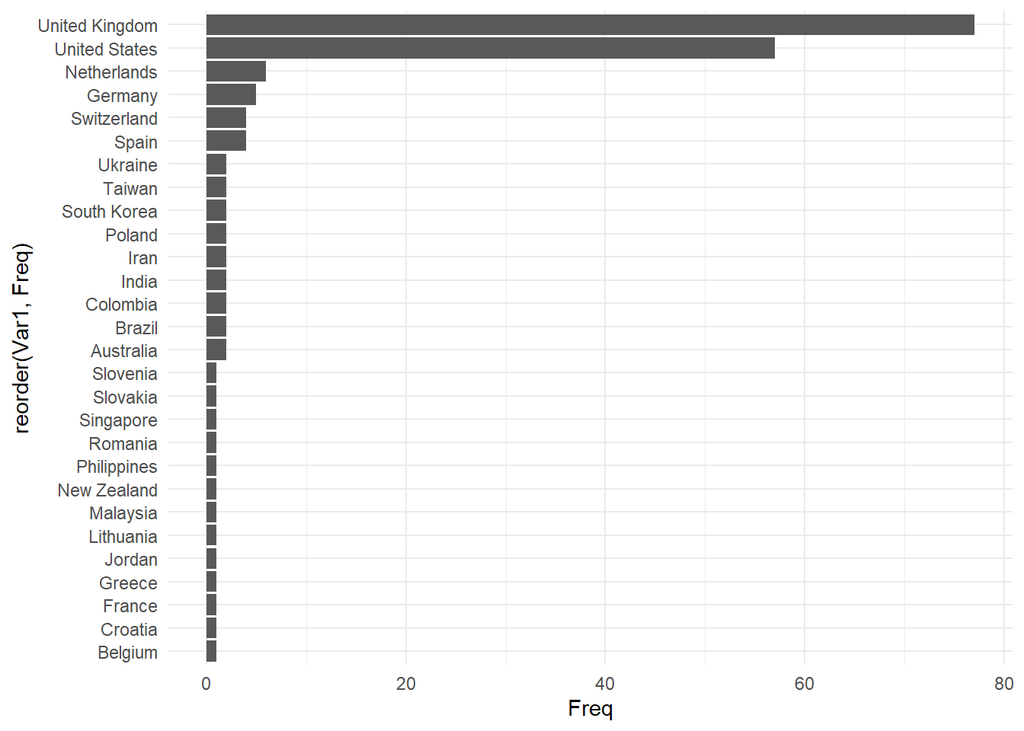

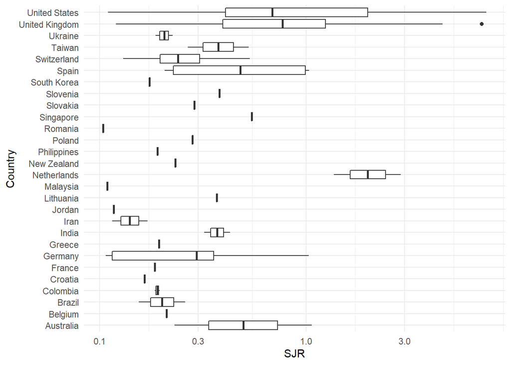

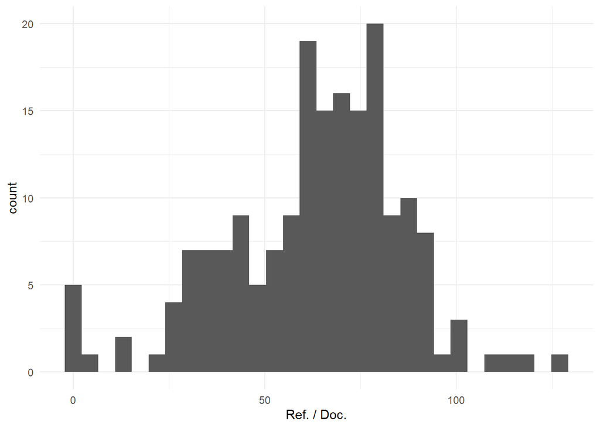

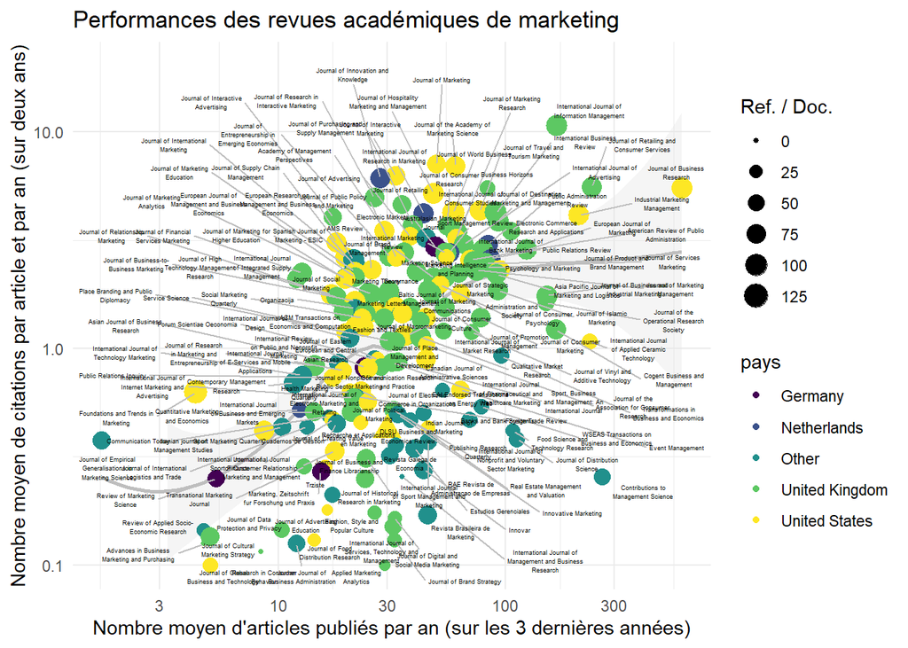

## Un regard par les éditeurs

Un peu de retraitement est nécessaire : certains éditeurs ont un pied au US et un autre en UK ou au Pays-Bas ( Elsevier). On note que l’AMA est son propre éditeur, que les historiques éditeurs universitaires tiennent une bonne position.

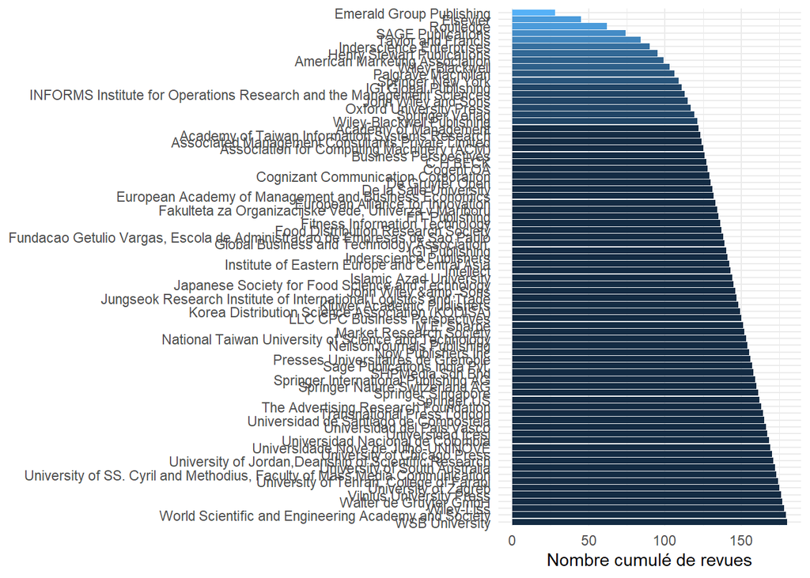

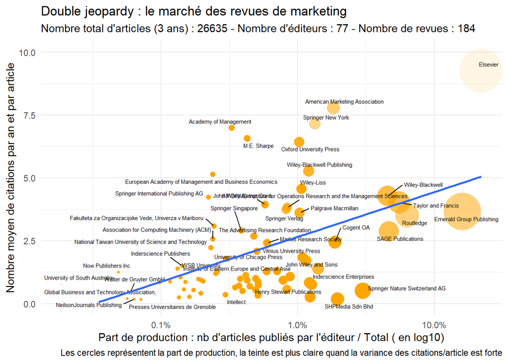